# lab_07_bootstrapping

Analysis of Environmental Data Lab 634

Emma Zimmerman Greenlee

2021-10-30

# Prelab

### Learning the apply() function

```r
# Create simulated data
dat = matrix(1:49, nrow = 7, ncol = 7)
print(dat)
```

```
##      [,1] [,2] [,3] [,4] [,5] [,6] [,7]
## [1,]    1    8   15   22   29   36   43
## [2,]    2    9   16   23   30   37   44
## [3,]    3   10   17   24   31   38   45
## [4,]    4   11   18   25   32   39   46
## [5,]    5   12   19   26   33   40   47
## [6,]    6   13   20   27   34   41   48
## [7,]    7   14   21   28   35   42   49
```

```r
apply(dat, MARGIN = 1, FUN = min)
```

```
## [1] 1 2 3 4 5 6 7
```

```r
apply(dat, MARGIN = 1, FUN = max)
```

```
## [1] 43 44 45 46 47 48 49
```

```r
apply(dat, MARGIN = 2, FUN = mean)
```

```
## [1]  4 11 18 25 32 39 46
```

### Load the Data Files

```r
require(here)
moths = read.csv(here("data", "moths.csv"))
head(moths)
```

```
##   site itame mepi cime  anst cahe  bare   acal   apde psca euma
## 1    4     0    0    0 1.000  1.0 0.000  0.667  2.500  0.0 0.00
## 2    5     0    0    0 1.000  0.0 0.000  0.000  0.000  1.5 0.00
## 3    6     0    2    0 0.000  2.5 0.000  0.667 10.000  0.0 0.00
## 4    7     0    0    3 5.000  0.0 1.667  0.500  2.333  1.5 0.00
## 5    8     0    0    0 0.000  4.5 0.000  0.667  4.000  3.0 0.75
## 6    9     5    0    0 6.333  1.0 1.667 16.667  1.333  7.0 2.75
```

### A simple bootstrap confidence interval

### Create the results vector

```r
m = 10000

# numeric() creates an vector of length m with all values initialized to zero
result = numeric(m)
head(result)
```

```
## [1] 0 0 0 0 0 0
```

### Perform the bootstrap

```r
anst = moths$anst

for(i in 1:m)
{
  result[i] = mean(sample(anst, replace=TRUE))
}
```

### Calculate the quantiles

```r
mean(result)
```

```
## [1] 2.472056
```

```r
quantile(result,c(0.025,0.975))
```

```
##     2.5%    97.5%
## 1.210019 3.986711
```

### Bootstrap Interval Using boot()

```r
#install.packages("boot")

require(boot)
# Basic syntax of boot: boot(data, statistic, R)
```

### Custom Mean Function

```r
# Create modified version of the mean() function that automatically excludes NAs
boot_mean = function(x, i)
{
  return(mean(x[i], na.rm = TRUE))
}

# Find the bootstrap for 10000 iterations
myboot =
  boot(
    data = moths$anst,
    statistic = boot_mean,
    R = 10000)
print(myboot)
```

```
##
## ORDINARY NONPARAMETRIC BOOTSTRAP
##
##
## Call:
## boot(data = moths$anst, statistic = boot_mean, R = 10000)
##
##
## Bootstrap Statistics :
##     original     bias    std. error
## t1* 2.470208 0.01091905   0.7299025
```

```r
# Check which other attributes are available for retrieval
str(myboot)
```

```
## List of 11
##  $ t0       : num 2.47
##  $ t        : num [1:10000, 1] 2.05 2.09 1.92 1.33 2.29 ...
##  $ R        : num 10000
##  $ data     : num [1:24] 1 1 0 5 0 ...
##  $ seed     : int [1:626] 10403 507 1888440319 1389807841 -2088829820 -1886560976 466525257 -2097369556 1517729796 70241209 ...
##  $ statistic:function (x, i)
##   ..- attr(*, "srcref")= 'srcref' int [1:8] 2 13 5 1 13 1 2 5
##   .. ..- attr(*, "srcfile")=Classes 'srcfilecopy', 'srcfile' <environment: 0x7fbc4075f708>
##  $ sim      : chr "ordinary"
##  $ call     : language boot(data = moths$anst, statistic = boot_mean, R = 10000)
##  $ stype    : chr "i"
##  $ strata   : num [1:24] 1 1 1 1 1 1 1 1 1 1 ...
##  $ weights  : num [1:24] 0.0417 0.0417 0.0417 0.0417 0.0417 ...
##  - attr(*, "class")= chr "boot"
##  - attr(*, "boot_type")= chr "boot"
```

```r
mean(moths$anst)
```

```
## [1] 2.470208
```

```r
myboot$t0
```

```
## [1] 2.470208
```

```r
mean(myboot$t) - myboot$t0
```

```
## [1] 0.01091905
```

```r
sd(myboot$t)
```

```
## [1] 0.7299025
```

```r
# Extract our bootstrap confidence interval
quantile(
  myboot$t,
  c(0.025, 0.975))
```

```
##     2.5%    97.5%
## 1.204456 4.094076
```

### Setting up the bootstrap

```r
moth_dat = moths[,-1]
head(moth_dat)
```

```
##   itame mepi cime  anst cahe  bare   acal   apde psca euma
## 1     0    0    0 1.000  1.0 0.000  0.667  2.500  0.0 0.00
## 2     0    0    0 1.000  0.0 0.000  0.000  0.000  1.5 0.00
## 3     0    2    0 0.000  2.5 0.000  0.667 10.000  0.0 0.00
## 4     0    0    3 5.000  0.0 1.667  0.500  2.333  1.5 0.00
## 5     0    0    0 0.000  4.5 0.000  0.667  4.000  3.0 0.75
## 6     5    0    0 6.333  1.0 1.667 16.667  1.333  7.0 2.75
```

```r
# Number of rows or sample observations
n = nrow(moth_dat)
# Number of bootstrap iterations
m = 100
moth_result = matrix(
  nrow = m,
  ncol = n)

# The outer loop: runs once for each bootstrap iteration.  index variable is i
for(i in 1:m)
{
  # The inner loop: simulates increasing sampling intensity
  # Sampling intensity ranges from 1 site to the complete count of sites (24)
  # index variable is j
  for(j in 1:n)
  {
    # Sample the input data row indices, with replacement
    rows_j = sample(n, size = j, replace=TRUE)

    # Creates a new data matrix from the resampled rows.
    t1 = moth_dat[rows_j, ]

    # Calculates the column sums of the new data matrix.
    t2 = apply(t1, 2, sum)

    # Counts the number of columns in which any moths were observed
    moth_result[i, j] = sum(t2 > 0)
  }
}

head(moth_result)
```

```
##      [,1] [,2] [,3] [,4] [,5] [,6] [,7] [,8] [,9] [,10] [,11] [,12] [,13] [,14]
## [1,]    2    8    9   10    9    9    9   10   10    10    10    10    10    10
## [2,]    2    5    4   10   10    9   10   10   10     9    10    10    10    10
## [3,]    2    8   10    9    9    5    8   10   10    10    10    10    10    10
## [4,]    3    7    7    9   10   10   10   10   10    10    10    10    10    10
## [5,]    2    7    8    8   10    9    9   10    9    10    10    10    10     9
## [6,]    4    8    6    8    8   10   10    9   10    10    10    10     9    10
##      [,15] [,16] [,17] [,18] [,19] [,20] [,21] [,22] [,23] [,24]
## [1,]     8    10    10    10    10    10    10    10    10    10
## [2,]    10    10    10    10    10    10    10    10    10    10
## [3,]    10    10    10    10    10    10    10    10    10    10
## [4,]    10    10    10    10    10    10    10    10    10    10
## [5,]    10    10    10    10    10    10    10    10    10    10
## [6,]    10    10    10    10    10    10    10    10    10    10
```

### Packaging your code into a function

### First draft

```r
rarefaction_sampler = function(input_dat, n_iterations)
{
  n = nrow(moth_dat) #number of rows or sample observations
  m = 100 #number of bootstrap iterations

  moth_result = matrix(
    nrow = m,
    ncol = n)

  # The outer loop: runs once for each bootstrap iteration.  index variable is i
  for(i in 1:m)
  {
    # The inner loop: simulates increasing sampling intensity
    # Sampling intensity ranges from 1 site to the complete count of sites (24)
    # index variable is j
    for(j in 1:n)
    {

      # sample the input data row indices, with replacement
      rows_j = sample(n, size = j, replace=TRUE)

      # Creates a new data matrix
      t1 = moth_dat[rows_j, ]

      # Calculates the column sums
      t2 = apply(t1, 2, sum)

      # Counts the number of columns in which any moths were observed
      moth_result[i, j] = sum(t2 > 0)
    }
  }

  return(moth_result)
}

rarefact = rarefaction_sampler(moth_dat, 100)
head(rarefact)
```

```
##      [,1] [,2] [,3] [,4] [,5] [,6] [,7] [,8] [,9] [,10] [,11] [,12] [,13] [,14]
## [1,]    5    8    8    9    8   10    9    9    9    10    10    10    10    10
## [2,]    7    4    9    9    9    9    7   10    8     8    10    10    10    10
## [3,]    8    7    8    9    7    9   10   10   10    10    10    10    10    10
## [4,]    3    5    9   10   10   10   10    8   10    10    10    10    10    10
## [5,]    4    6    4    8    9    7    8    9   10    10    10     9    10    10
## [6,]    2    8    7   10    8   10   10   10    9    10    10    10    10     9
##      [,15] [,16] [,17] [,18] [,19] [,20] [,21] [,22] [,23] [,24]
## [1,]    10    10    10    10    10    10    10    10    10    10
## [2,]    10    10    10    10    10    10    10    10    10    10
## [3,]    10    10    10    10    10    10    10    10    10    10
## [4,]    10    10    10    10    10    10    10    10    10    10
## [5,]    10    10    10    10    10    10    10    10    10    10
## [6,]    10    10    10    10    10    10    10    10    10    10
```

### Second draft

```r
rarefaction_sampler = function(input_dat, n_iterations)
{
  n_input_rows = nrow(input_dat)

  results_out = matrix(
    nrow = n_iterations,
    ncol = n_input_rows)

  # The outer loop: runs once for each bootstrap iteration.  index variable is i
  for(i in 1:n_iterations)
  {
    # The inner loop: simulates increasing sampling intensity
    # Sampling intensity ranges from 1 site to the complete count of
    # sites in the input data (n)
    # index variable is j
    for(j in 1:n)
    {
      # sample the input data row indices, with replacement
      rows_j = sample(n, size = j, replace=TRUE)

      # Creates a new data matrix
      t1 = input_dat[rows_j, ]

      # Calculates the column sums
      t2 = apply(t1, 2, sum)

      # Counts the number of columns in which any moths were observed
      results_out[i, j] = sum(t2 > 0)
    }
  }
  return(results_out)
}

rarefact = rarefaction_sampler(moth_dat, 100)
head(rarefact)
```

```
##      [,1] [,2] [,3] [,4] [,5] [,6] [,7] [,8] [,9] [,10] [,11] [,12] [,13] [,14]
## [1,]    2    6    9    8    9   10    7   10    9     9    10    10    10    10
## [2,]    3    8   10    8    5    7   10   10   10    10    10     9    10    10
## [3,]    6    9    8   10    8    9    9    9   10     8    10    10    10    10
## [4,]    3    8    8    9    7   10    8   10   10     9    10     9     9     9
## [5,]    6    5    8    9    8   10    9    9   10     8    10    10    10    10
## [6,]    4    6    8    8    9   10   10   10   10    10    10    10     8     9
##      [,15] [,16] [,17] [,18] [,19] [,20] [,21] [,22] [,23] [,24]
## [1,]    10    10    10    10    10    10    10    10    10    10
## [2,]    10    10    10    10    10    10    10    10    10    10
## [3,]    10     9    10    10    10    10    10    10    10    10
## [4,]    10    10    10    10    10     9    10    10    10    10
## [5,]    10    10    10    10    10    10    10    10    10    10
## [6,]    10    10    10    10    10    10    10    10    10    10
```

### Check in a fresh environment

```r
# This clears the current R session's environment
# rm(list = ls())

# Re-read my data:
moths = read.csv(here::here("data", "moths.csv"))
moth_dat = moths[,-1]

rarefaction_sampler = function(input_dat, n_iterations)
{
  n_input_rows = nrow(input_dat)

  results_out = matrix(
    nrow = n_iterations,
    ncol = n_input_rows)

  # The outer loop: runs once for each bootstrap iteration.  index variable is i
  for(i in 1:n_iterations)
  {
    # The inner loop: simulates increasing sampling intensity
    # Sampling intensity ranges from 1 site to the complete count of
    # sites in the input data (n)
    for(j in 1:n_input_rows)
    {
      # sample the input data row indices, with replacement
      rows_j = sample(n_input_rows, size = j, replace=TRUE)

      # Creates a new data matrix
      t1 = input_dat[rows_j, ]

      # Calculates the column sums
      t2 = apply(t1, 2, sum)

      # Counts the number of columns in which any moths were observed
      results_out[i, j] = sum(t2 > 0)
    }
  }
  return(results_out)
}

rarefact = rarefaction_sampler(moth_dat, 100)
head(rarefact)
```

```
##      [,1] [,2] [,3] [,4] [,5] [,6] [,7] [,8] [,9] [,10] [,11] [,12] [,13] [,14]
## [1,]    8    5    9    7    9   10   10   10    9    10    10    10     9    10
## [2,]    2    8    5    9    9    9   10   10   10    10    10    10    10    10
## [3,]    6    4    8    7    9    9   10    9   10    10    10    10     9    10
## [4,]    6    7    6    9   10    9    8   10   10    10    10     9    10    10
## [5,]    8    8    8    9    8    8   10   10   10    10     9     9     9    10
## [6,]    5    4    8    9   10    9    8   10   10     9    10    10    10     9
##      [,15] [,16] [,17] [,18] [,19] [,20] [,21] [,22] [,23] [,24]
## [1,]    10    10     9    10    10    10    10    10    10    10
## [2,]    10     9    10    10    10    10    10    10    10    10
## [3,]    10    10    10    10    10    10    10    10    10    10
## [4,]    10    10    10    10    10    10    10    10    10    10
## [5,]    10     9    10    10    10    10    10    10    10    10
## [6,]    10    10    10    10    10    10    10    10    10    10
```

### Debugging template

```r
# This clears the current R session's environment
# rm(list = ls())

# Re-read my data:
moths = read.csv(here("data", "moths.csv"))

rarefaction_sampler = function(input_dat, n_iterations)
{
    n_input_rows = nrow(input_dat)

  results_out = matrix(
    nrow = n_iterations,
    ncol = n_input_rows)

  # The outer loop: runs once for each bootstrap iteration.  index variable is i
  for(i in 1:n_iterations)
  {
    # The inner loop: simulates increasing sampling intensity
    # Sampling intensity ranges from 1 site to the complete count of
    # sites in the input data (n)
    # index variable is j
    for(j in 1:n)
    {
      # sample the input data row indices, with replacement
      rows_j = sample(n, size = j, replace=TRUE)

      # Creates a new data matrix
      t1 = input_dat[rows_j, ]

      # Calculates the column sums
      t2 = apply(t1, 2, sum)

      # Counts the number of columns in which any moths were observed
      results_out[i, j] = sum(t2 > 0)
    }
  }
  return(results_out)
}

rarefact = rarefaction_sampler(moth_dat, 100)
head(rarefact)
```

```
##      [,1] [,2] [,3] [,4] [,5] [,6] [,7] [,8] [,9] [,10] [,11] [,12] [,13] [,14]
## [1,]    2    9    5    8   10   10    9   10   10     9    10     9    10    10
## [2,]    3    8    8    9    8    9   10   10   10    10    10    10    10    10
## [3,]    6    8    4    5    9    8    8   10    8    10     9    10    10    10
## [4,]    8    7    7    9    9    9   10    8   10    10     9    10    10    10
## [5,]    4    8    6    9   10   10   10    9   10    10     9    10    10     9
## [6,]    8    8    9    9   10   10    9    9    9    10    10    10     9    10
##      [,15] [,16] [,17] [,18] [,19] [,20] [,21] [,22] [,23] [,24]
## [1,]    10    10    10    10    10    10    10    10    10    10
## [2,]    10    10    10    10    10    10    10    10    10    10
## [3,]    10    10    10    10    10    10    10    10    10    10
## [4,]    10    10    10    10     9    10    10    10    10    10
## [5,]    10    10    10    10    10    10    10    10    10    10
## [6,]    10    10     9     9    10    10    10    10    10    10
```

```r
print(n)
```

```
## [1] 24
```

### Check in a fresh environment

```r
# This clears the current R session's environment
rm(list = ls())

# Re-read my data:
moths = read.csv(here::here("data", "moths.csv"))
moth_dat = moths[,-1]

rarefaction_sampler = function(input_dat, n_iterations)
{
  n_input_rows = nrow(input_dat)

  results_out = matrix(
    nrow = n_iterations,
    ncol = n_input_rows)

  # The outer loop: runs once for each bootstrap iteration.  index variable is i
  for(i in 1:n_iterations)
  {
    # The inner loop: simulates increasing sampling intensity
    # Sampling intensity ranges from 1 site to the complete count of
    # sites in the input data (n)
    for(j in 1:n_input_rows)
    {
      # sample the input data row indices, with replacement
      rows_j = sample(n_input_rows, size = j, replace=TRUE)

      # Creates a new data matrix
      t1 = input_dat[rows_j, ]

      # Calculates the column sums
      t2 = apply(t1, 2, sum)

      # Counts the number of columns in which any moths were observed
      results_out[i, j] = sum(t2 > 0)
    }
  }
  return(results_out)
}

rarefact = rarefaction_sampler(moths[,-1], 100)
head(rarefact)
```

```
##      [,1] [,2] [,3] [,4] [,5] [,6] [,7] [,8] [,9] [,10] [,11] [,12] [,13] [,14]
## [1,]    4    5    7    5    8    8    8    9   10     9    10    10    10    10
## [2,]    3    8    5    7    8    9    9   10   10    10    10    10    10    10
## [3,]    7    7    6    8    9   10    8   10   10    10     9     9     9    10
## [4,]    4    9    6    9    9    9   10   10    8     9    10    10    10    10
## [5,]    8    6    3    8    8    8   10    9   10     9    10     8    10    10
## [6,]    4    7    8    7    7    8   10   10   10    10    10     9    10    10
##      [,15] [,16] [,17] [,18] [,19] [,20] [,21] [,22] [,23] [,24]
## [1,]    10    10    10    10    10    10    10    10    10    10
## [2,]    10    10    10    10    10    10    10    10    10    10
## [3,]     9    10    10    10    10    10    10    10    10    10
## [4,]    10    10    10    10    10    10    10    10    10    10
## [5,]    10    10    10    10    10    10    10    10    10    10
## [6,]    10    10    10    10    10    10    10    10    10    10
```

### Building the Rarefaction Curve

```r
# Re-read my data:
moths = read.csv(here("data", "moths.csv"))
rarefact = rarefaction_sampler(moths[,-1], 10000)

rare_mean = apply(rarefact, 2, mean)
rare_quant = apply(rarefact, 2, quantile, probs=c(0.025, 0.975))
rare = t(rbind(rare_mean, rare_quant))
```

### Plotting the curve

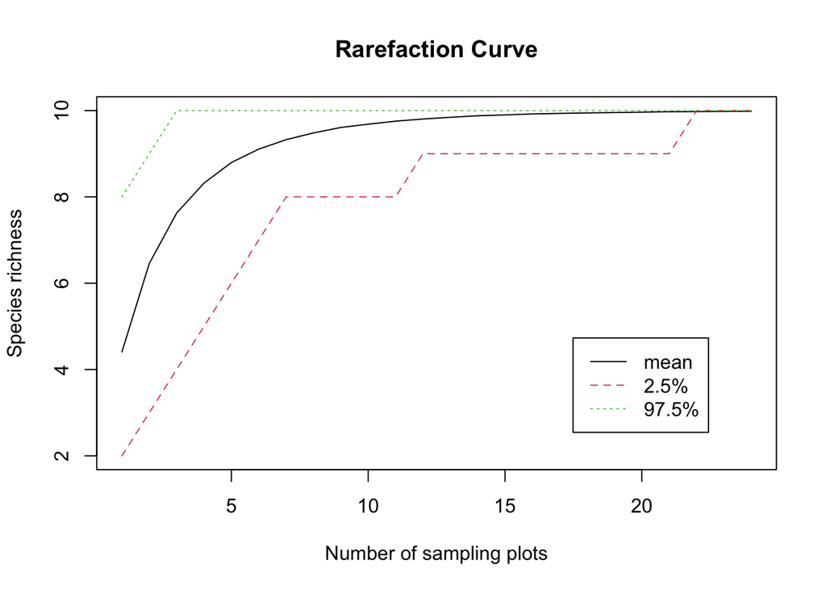

```r
matplot(
  rare,
  type='l',
  xlab='Number of sampling plots',
  ylab='Species richness',
  main='Rarefaction Curve')

legend(
  'bottomright',
  legend=c('mean','2.5%','97.5%'),
  lty=c(1,2,3),col=c(1,2,3), inset=c(.1,.1))
```

# Lab Questions

```r
require(palmerpenguins)
dat_pen = subset(penguins, species == "Gentoo")
billL = dat_pen$bill_length_mm

# Calculate sample size
n = length(billL) - sum(is.na(billL)); n
```

```
## [1] 123
```

```r
# Calculate sample standard deviation
ssd = sd(billL, na.rm = TRUE); ssd
```

```
## [1] 3.081857
```

```r
# Calculate sample standard error
sse = ssd / sqrt(n); sse
```

```
## [1] 0.2778817
```

```r
# Calculate critical t-values using alpha value (1 - 0.95)
alpha = 0.05

t_crit = qt(c(0.025, 0.975), df = (n - 1))

# Calculate the CI
ci_parametric = t_crit * sse; ci_parametric
```

```
## [1] -0.5500946  0.5500946
```

## Question 1

### What is the sample size, n? Show the code you used for the calculation and remember to check for missing data.

The sample size is the number of observations of the bill length of Gentoo penguins in the penguins data set.

```r
# Calculate sample size
n = length(billL) - sum(is.na(billL)); n
```

```
## [1] 123
```

## Question 2

### What is the sample standard deviation? Show the code you used for the calculation.

The standard deviation is how much varience there is between the observations of Gentoo bill length in the sample size.

```r
# Calculate sample standard deviation
ssd = sd(billL, na.rm = TRUE); ssd
```

```
## [1] 3.081857
```

## Question 3

### What are the critical t-values? Show the R code you used for the calculation.

```r
# Calculate critical t-values using alpha value (1 - 0.95)
alpha = 0.05

t_crit1 = qt(c(0.025, 0.975), df = (n - 1))
```

## Question 4

### What is the sample standard error? Show the R code you used for the calculation.

The sample standard error is how accurately the sample of Gentoo penguin bill length represents the actual overall population.

```r
# Calculate sample standard error
sse = ssd / sqrt(n); sse
```

```
## [1] 0.2778817
```

## Question 5

### Finally, construct the CI and show the R code you used for the calculation.

47.50 +/- 0.55

```r
# Calculate the CI
mean(billL, na.rm = TRUE)
```

```
## [1] 47.50488
```

```r
ci_parametric = t_crit1 * sse; ci_parametric
```

```
## [1] -0.5500946  0.5500946
```

## Question 7

### Show the r code you used to call the boot() function.

```r
# install.packages("boot")
require(boot)

boot_mean = function(x, i)
{
  return(mean(x[i], na.rm = TRUE))
}

pen_boot = boot(data = dat_pen$bill_length_mm,
                statistic = boot_mean,
                R = 10000)
print(pen_boot)
```

```
##
## ORDINARY NONPARAMETRIC BOOTSTRAP
##
##
## Call:
## boot(data = dat_pen$bill_length_mm, statistic = boot_mean, R = 10000)
##
##
## Bootstrap Statistics :
##     original       bias    std. error
## t1* 47.50488 -0.002208604   0.2767472
```

```r
str(pen_boot)
```

```
## List of 11
##  $ t0       : num 47.5
##  $ t        : num [1:10000, 1] 47.4 47.1 47.7 47.5 47.3 ...
##  $ R        : num 10000
##  $ data     : num [1:124] 46.1 50 48.7 50 47.6 46.5 45.4 46.7 43.3 46.8 ...
##  $ seed     : int [1:626] 10403 422 1510601645 1930742594 -959318044 2063421844 -1951179292 1839187454 -741008728 1984029543 ...
##  $ statistic:function (x, i)
##   ..- attr(*, "srcref")= 'srcref' int [1:8] 4 13 7 1 13 1 4 7
##   .. ..- attr(*, "srcfile")=Classes 'srcfilecopy', 'srcfile' <environment: 0x7fbc42321ce0>
##  $ sim      : chr "ordinary"
##  $ call     : language boot(data = dat_pen$bill_length_mm, statistic = boot_mean, R = 10000)
##  $ stype    : chr "i"
##  $ strata   : num [1:124] 1 1 1 1 1 1 1 1 1 1 ...
##  $ weights  : num [1:124] 0.00806 0.00806 0.00806 0.00806 0.00806 ...
##  - attr(*, "class")= chr "boot"
##  - attr(*, "boot_type")= chr "boot"
```

```r
mean(dat_pen$bill_length_mm, na.rm = TRUE)
```

```
## [1] 47.50488
```

```r
pen_boot$t0
```

```
## [1] 47.50488
```

```r
mean(pen_boot$t, na.rm = TRUE) - pen_boot$t0
```

```
## [1] -0.002208604
```

```r
sd(pen_boot$t)
```

```
## [1] 0.2767472
```

## Question 8

### Show the r code you used to calculate the upper and lower 2.5% quantiles.

```r
quantile(
  pen_boot$t,
  c(0.025, 0.975))
```

```
##     2.5%    97.5%
## 46.97823 48.05043
```

## Question 9

### Show your completed rarefaction_sampler() function.

```r
# Re-read my data:
moths = read.csv(here::here("data", "moths.csv"))
moth_dat = moths[,-1]

rarefaction_sampler = function(input_dat, n_iterations)
{
  n_input_rows = nrow(input_dat)

  results_out = matrix(
    nrow = n_iterations,
    ncol = n_input_rows)

  for(i in 1:n_iterations)
  {
    for(j in 1:n_input_rows)
    {
      rows_j = sample(n_input_rows, size = j, replace=TRUE)

      t1 = input_dat[rows_j, ]

      t2 = apply(t1, 2, sum)

      results_out[i, j] = sum(t2 > 0)
    }
  }
  return(results_out)
}

rarefact = rarefaction_sampler(moths[,-1], 100)
head(rarefact)
```

```
##      [,1] [,2] [,3] [,4] [,5] [,6] [,7] [,8] [,9] [,10] [,11] [,12] [,13] [,14]
## [1,]    4    8    8    7    9   10   10    8    9    10     9    10    10    10
## [2,]    6    8    4    6    8   10    9   10   10    10     9    10     9    10
## [3,]    6    8   10    8   10    9    9    9   10     9    10    10     9    10
## [4,]    4    4    8    9    8    9   10    9   10     9     9    10    10    10
## [5,]    8    6    7    8    8   10    8   10   10     9    10     8    10    10
## [6,]    2    8    7   10    9    8    9    9   10    10    10    10    10    10
##      [,15] [,16] [,17] [,18] [,19] [,20] [,21] [,22] [,23] [,24]
## [1,]    10    10    10    10    10    10    10    10    10    10
## [2,]    10    10    10    10    10    10    10    10    10    10
## [3,]    10    10    10    10    10    10    10    10    10    10
## [4,]    10    10    10    10    10    10    10    10    10    10
## [5,]    10    10    10    10    10    10    10    10    10     9
## [6,]    10    10    10     9    10    10    10    10    10    10
```

## Question 10

### What did you find most difficult about building the function?

I found it really difficult to understand what each variable was referring to in the context of the function. I mostly get the concepts involved, but when I have to actually interact wiht the function it’s different than just reading it, and I need to have a different level of understanding.

## Questions 11 and 12

### Show the code you used to perform the simulations and construct the curve.

### Include your rarefaction curve plot in your report. Show the R-code you used to create your plot.

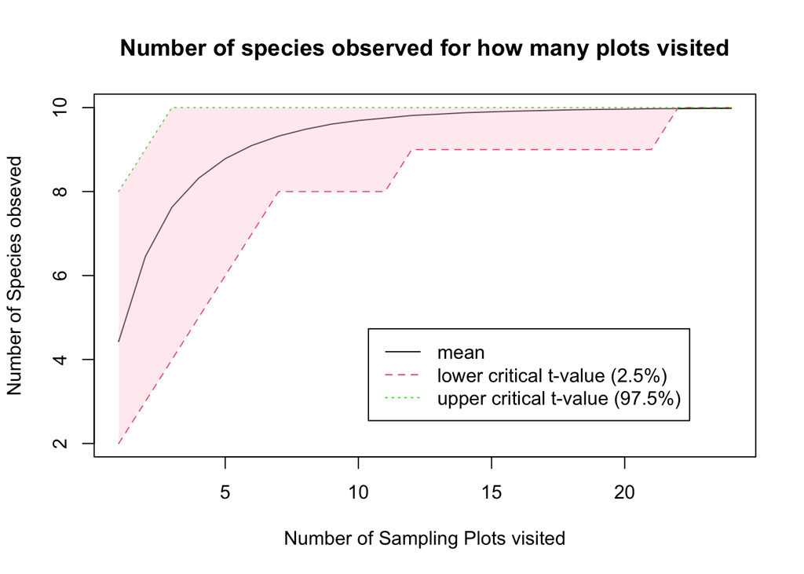

```r
# Rarefaction curve
# Re-read my data:
moths = read.csv(here("data", "moths.csv"))
rarefact = rarefaction_sampler(moths[,-1], 10000)

rare_mean = apply(rarefact, 2, mean)
rare_quant = apply(rarefact, 2, quantile, probs=c(0.025, 0.975))
rare = t(rbind(rare_mean, rare_quant))

matplot(
  rare,
  type='l',
  xlab='Number of Sampling Plots visited',
  ylab='Number of Species obseved',
  main='Number of species observed for how many plots visited')

legend(
  'bottomright',
  legend=c('mean','lower critical t-value (2.5%)','upper critical t-value (97.5%)'),
  lty=c(1,2,3),col=c(1,2,3), inset=c(.1,.1))

x = c(1:24)
y1 = rare[,2]
y2 = rare[,3]

polygon(c(x, rev(x)) , c(y1, rev(y2)),
        col = rgb(255, 209, 220, 100, maxColor = 255), lty = 0)
```